# Gini Coefficient and Income per Person – Global Report (2020)

## Introduction

This report examines two key development indicators for the year 2020:

1. **Gini Coefficient** – a measure of income inequality within a country, where 0 represents perfect equality and 100 represents perfect inequality.
2. **Income per Person (GDP per capita, PPP in 2021 US dollars)** – a measure of economic output per person adjusted for purchasing power parity.

The data is sourced from the Gapminder dataset.

## World Map: Gini Coefficient (2020)

The map below shows the Gini coefficient for countries around the world in 2020. Darker shades indicate higher inequality.

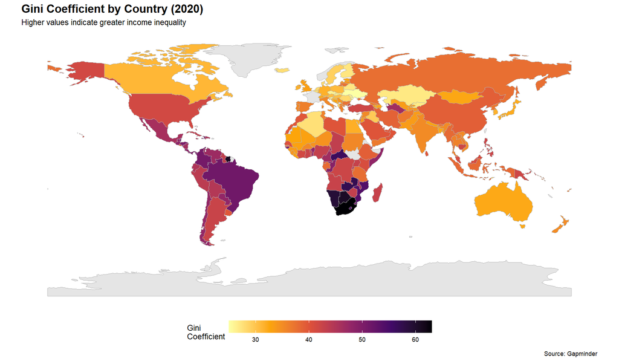

## World Map: Income per Person (2020)

The map below shows income per person (GDP per capita, PPP) for countries around the world in 2020. A logarithmic scale is used to better distinguish between countries at different income levels.

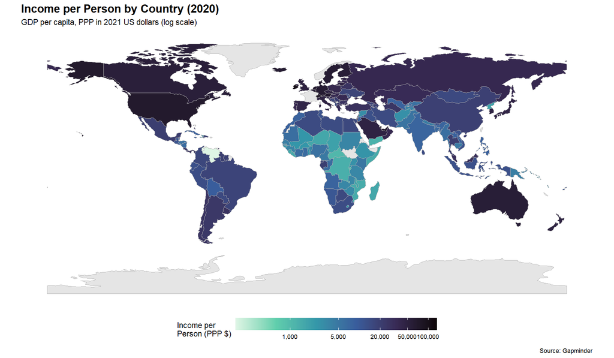

## Relationship between Gini Coefficient and Income per Person

The scatterplot below examines the relationship between the Gini coefficient and income per person across 191 countries.

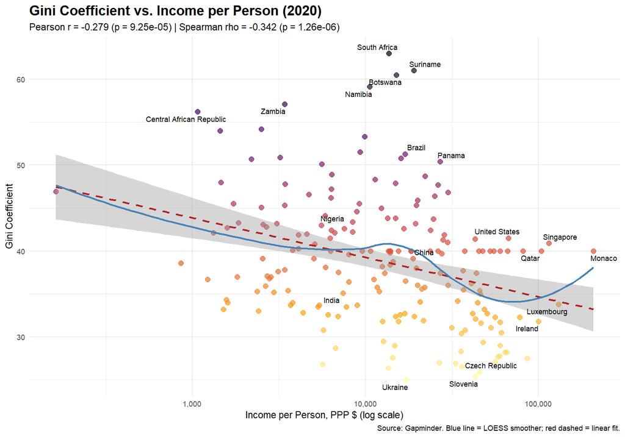

### Correlation Analysis

The **Pearson correlation coefficient** between the Gini coefficient and income per person is **r = -0.279** (p = 9.25e-05), and the **Spearman rank correlation** is **rho = -0.342** (p = 1.26e-06).

## Interpretation

The scatterplot reveals a **weak negative relationship** between income inequality (Gini coefficient) and income per person. Countries with higher incomes per person tend to have slightly lower Gini coefficients, suggesting that wealthier nations are somewhat more equal in their income distributions. However, the relationship is far from deterministic, and there is considerable scatter around any trend line.

Overall, while income level provides some information about a country’s inequality, many other factors – including historical, institutional, and policy-related differences – play crucial roles in determining income distribution within a country.

## Reflection

Great exercise, very impressive! My reflection is that the code should be checked by an experienced programmer. I will need to become more proficient in R to at least check the gist of the code… I got a bit frustrated with this exercise because I wanted to use cursor but got stuck because I did not have admin rights. This has now been sorted.